# 🧬 SARS-CoV-2 Whole Genome Variant Analysis Report

Chijioke Uhegwu

28-04-2025

**Data Source:** Variant annotations from whole genome sequencing of SARS-CoV-2 samples  
**Tools Used:** Bash, Nextflow, R.

## 📘 Overview

This report provides a comprehensive exploration of variants identified from whole genome sequencing (WGS) of SARS-CoV-2 samples. The initial processing and analysis were conducted using the ViralRecon pipeline on Nextflow via Bash scripting, which enabled high-throughput quality control, read mapping, variant calling, and consensus sequence generation. Using visual analytics in R, I aimed to uncover the biological patterns behind mutation distribution, variant types, amino acid substitutions, and more.

## 1. 🔬 Distribution of Variants per Gene

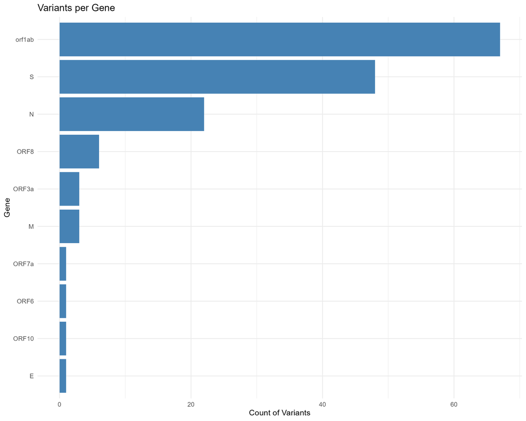

## 2. 🧠 Functional Effect of Variants

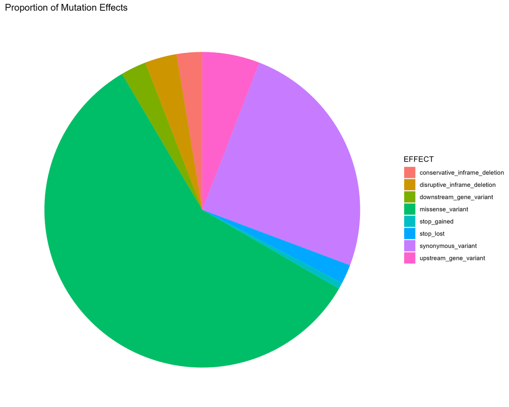

## 3. 🌡️ Heatmap of Mutation Density Across Genome

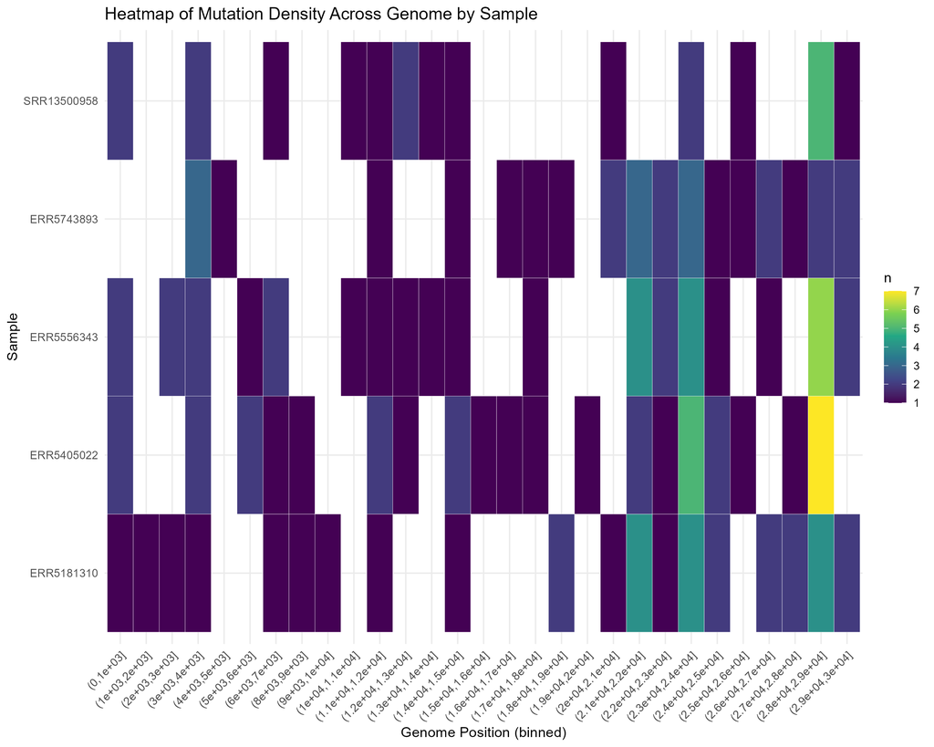

### 📌 Interpretation:

- Certain genome regions, such as 21,000–25,000 (S gene region), show **higher mutation density**.
- This suggests evolutionary hotspots and potential selective pressure.
- Mutational clustering may align with **emerging variants of concern (VOCs)**.

## 4. 🧬 Top Amino Acid Changes

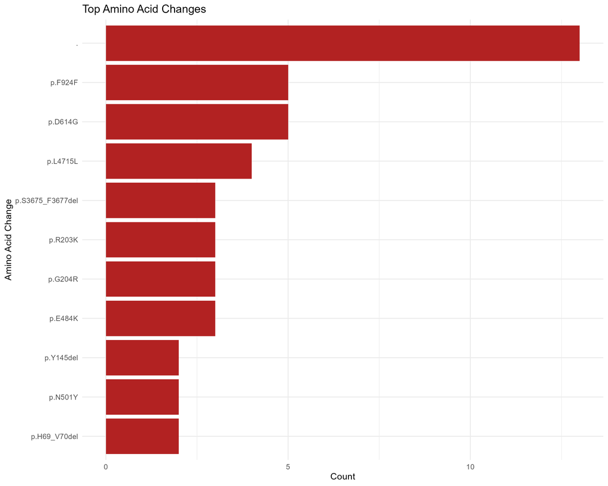

## 5. 📈 Allele Frequency Distribution

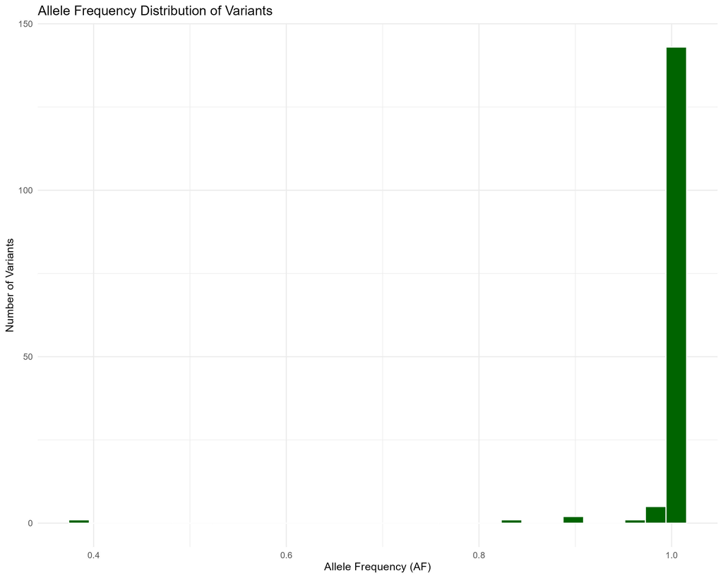

### 📌 Interpretation:

- Most mutations have an **allele frequency close to 1**, indicating they are **fixed or dominant** in those samples.
- Variants with lower allele frequency may be **emerging** or represent **intra-host diversity**.
- This insight is crucial for understanding **viral population dynamics** within hosts.

## 6. 👥 Variants per Sample

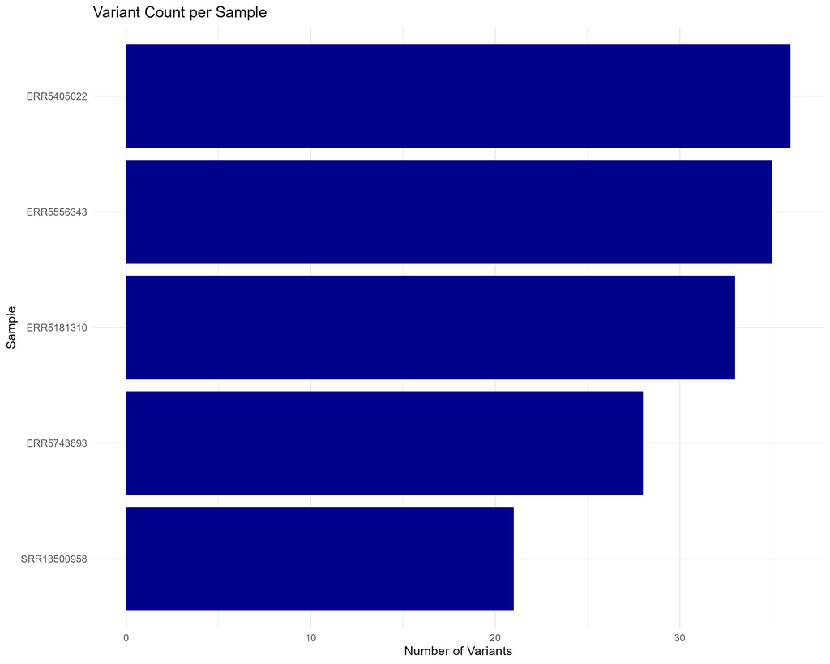

### 📌 Interpretation:

- Some samples contain more variants, which may be due to **prolonged infection**, **host immune status**, or sequencing depth.
- Tracking mutation load per sample can help identify **hypermutated viruses** or **host-driven mutation pressure**.

## 🧩 Summary

This analysis shows that: - The **Spike protein** is a major site of evolutionary change in SARS-CoV-2. - Mutations like **D614G** and **E484K** have major implications for **transmission and immune escape**. - Variant allele frequencies suggest both **dominant and emerging variants** within the population. - This kind of genomic surveillance can guide **public health decisions** and **vaccine updates**.

## 🚀 Next Steps

- Extend analysis to **lineage classification** (e.g. using Pangolin).
- Compare to global datasets to track **variant spread**.
- Build a Shiny dashboard for **interactive exploration**.

## ✍️ Citation

If using this report, please cite as:  
> [Chijioke Uhegwu]. “SARS-CoV-2 Whole Genome Variant Analysis.” GitHub. [https://github.com/ChijiokeUhegwu/viralrecon], 2025.

## 📬 Contact

For questions or collaboration:  
📧 [chijiokeuhegwu@gmail.com]  
🔗 GitHub: [ChijiokeUhegwu]